# Project1

MikeOfNoTrades

2015-12-17

## Data Description

This assignment makes use of data from a personal activity monitoring device. This device collects data at 5 minute intervals through out the day. The data consists of two months of data from an anonymous individual collected during the months of October and November

The variables included in this dataset are:

steps: Number of steps taking in a 5-minute interval (missing values are coded as NA)

date: The date on which the measurement was taken in YYYY-MM-DD format

The dataset is stored in a comma-separated-value (CSV) file and there are a total of 17,568 observations in this dataset.

### Get Data

```r
setwd(dir = "~/work/data/reproducible_research/RepData_PeerAssessment1/")
p1_data <- read.csv("activity.csv")
```

### Steps per day

```r
library(dplyr)
```

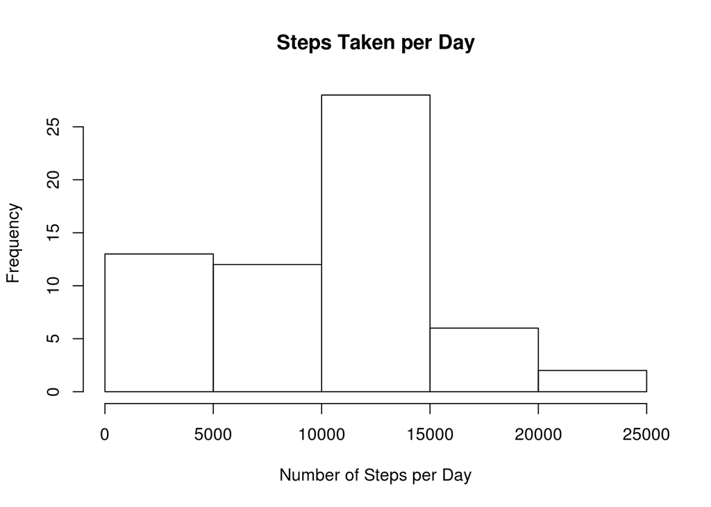

```r
steps_per_date <- group_by(p1_data, date)
steps_per_date <- summarize(steps_per_date, STEPS = sum(steps, na.rm = TRUE))
hist(steps_per_date$STEPS, main="Steps Taken per Day", xlab="Number of Steps per Day")
```

```r
mean_steps <- mean(steps_per_date$STEPS)
median_steps <- median(steps_per_date$STEPS)
```

Mean steps per day: 9354.2295082  
Median steps per day: 10395

### Time Series

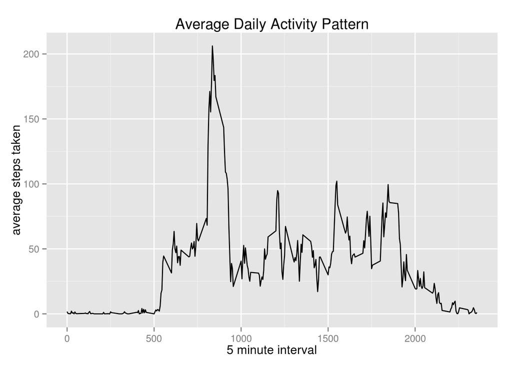

```r
library(ggplot2)
p1_data_complete <- p1_data[complete.cases(p1_data), ]
steps_per_interval <- group_by(p1_data_complete, interval)
summary_spi <- summarize(steps_per_interval, AV_STEPS = mean(steps, na.rm = TRUE))
max_av_steps <- max(summary_spi$AV_STEPS)
max_int_row <- filter(summary_spi, AV_STEPS == max_av_steps)
max_int <- max_int_row$interval
ggplot(data=summary_spi, aes(x=interval, y=AV_STEPS), na.omit()) +
     geom_line() +
     ggtitle("Average Daily Activity Pattern") +
     labs(x="5 minute interval",y="average steps taken")
```

Interval at which the maximimum average steps were taken: 835

### Imputing missing values

There are a number of days/intervals where there are missing values (coded as NA). The presence of missing days may introduce bias into some calculations or summaries of the data.

```r
steps_na <- sum(is.na(p1_data$steps))
steps_na
```

```
## [1] 2304
```

```r
date_na <- sum(is.na(p1_data$date))
date_na
```

```
## [1] 0
```

```r
int_na <- sum(is.na(p1_data$interval))
int_na
```

```
## [1] 0
```

the steps variable is the only variable to contain NAs, with 2304 NAs.

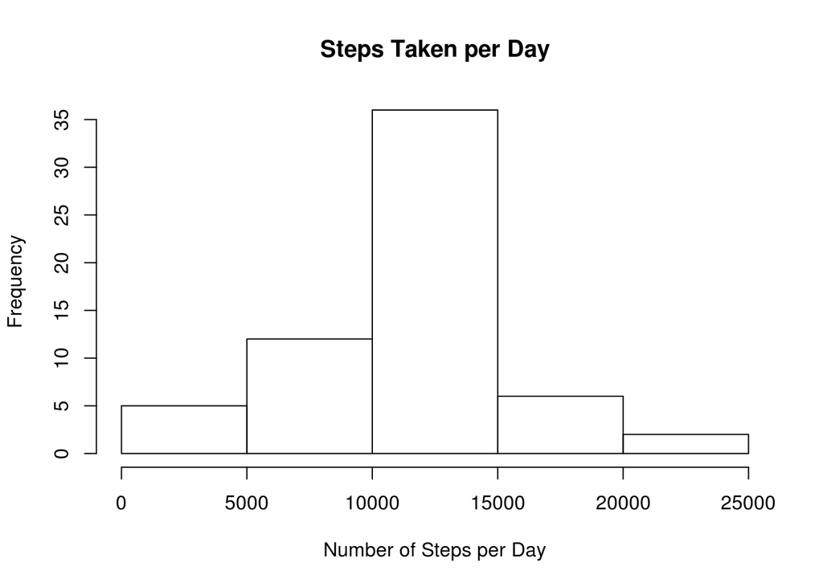

```r
#interval_means <- summarize(steps_per_interval, mean(steps))
#na_indices <- which(is.na(p1_data$steps))
p1_data_nona <- p1_data
p1_data_nona$steps[is.na(p1_data$steps)] = mean(p1_data_nona$steps, na.rm=TRUE)
steps_per_date <- group_by(p1_data_nona, date)
steps_per_date <- summarize(steps_per_date, STEPS = sum(steps, na.rm = TRUE))
hist(steps_per_date$STEPS, main="Steps Taken per Day", xlab="Number of Steps per Day")
```

```r
mean_steps <- mean(steps_per_date$STEPS)
median_steps <- median(steps_per_date$STEPS)
```

As we can see, imputing values raised the number of stpes per day.

### Differences in activity patterns between weekdays and weekends

We will create a new factor variable in the dataset with two levels – “weekday” and “weekend” indicating whether a given date is a weekday or weekend day.

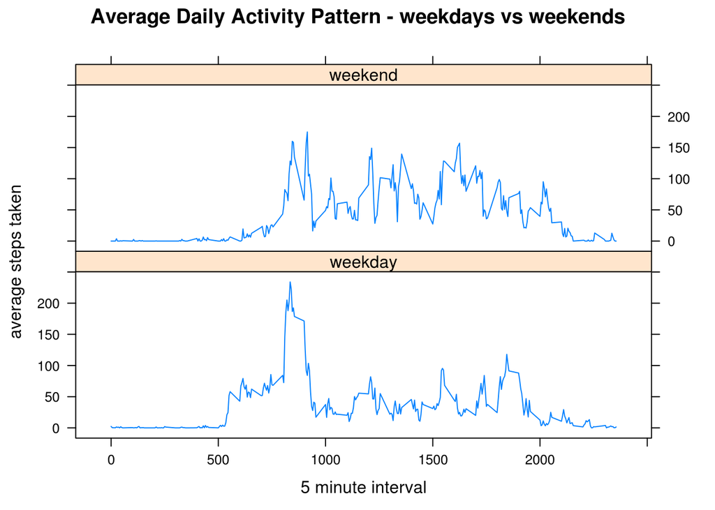

```r
p1_data_complete <- p1_data[complete.cases(p1_data), ]
p1_data_days <- mutate(p1_data_complete, weekend =  chron::is.weekend(as.Date(p1_data_complete$date)))
p1_data_days$weekend <- as.factor(ifelse(p1_data_days$weekend == TRUE, "weekend", "weekday"))

#p1_data_complete <- p1_data[complete.cases(p1_data), ]
#p1_data_days$weekend <- as.factor(ifelse(p1_data_days$weekend == TRUE, "weekend", "weekday"))
#steps_per_interval <- group_by(p1_data_complete, interval)
steps_per_interval <- group_by(p1_data_days, interval, weekend)
summary_spi <- summarize(steps_per_interval, AV_STEPS = mean(steps, na.rm = TRUE))

# panel plot
library(lattice)
xyplot(AV_STEPS~interval | weekend, data=summary_spi, pch=19,
                main="Average Daily Activity Pattern - weekdays vs weekends",
      xlab="5 minute interval",  ylab="average steps taken",layout=c(1,2),type="l")
```